# AIDC_dataAnalysis_lowEntropy

2024-03-18

## Packages

Load your packages here

```r
library(ggplot2)
library(RColorBrewer)
library(dplyr)
library(stringr)
library(corrplot)
library(tidyverse)
library(lme4)
library(car)
library(wesanderson)
library(knitr)
library(gridExtra)
library(patchwork)
library(MASS)
library(ggpubr)
library(rstatix)
library(dunn.test)
library(bestNormalize)
library(mvnormtest)
library(clinfun)
library(BSDA)
library(vegan)
library(permute)
```

## Data Cleaning

Time was converted to seconds, and data was removed where the experiment conductor recommended throwing out the data.

```r
data.raw <- read.csv("AIDC_anon_lowE_data.csv", header = TRUE)


#filter out data with bad readings
data <- data.raw %>%
  filter(!grepl("^throw out", Comments, ignore.case = TRUE))

# Convert time to total seconds
data$TimeSec <- with(data, {
  time_parts <- strsplit(as.character(Time), ":")
  minutes_to_seconds <- as.numeric(sapply(time_parts, `[`, 1)) * 60
  seconds <- as.numeric(sapply(time_parts, `[`, 2))
  minutes_to_seconds + seconds
})

#remove columns
data <- data %>% select(-Comments, -Recorded, -Correct, -Time)

#write.csv(data, "simple_data.csv", row.names = FALSE)
```

## Global Statistics

Note these are calculated per device/system and not split per location as well, this would yield slightly different results. This process is done to normalize the data before statistical analysis.

```r
#IMPORTANT: getting the stats just by device, not device and location

grouped_stats <- data %>%
  group_by(#Location,
           System
           ) %>%
  summarise(
     n = n(),  # Count the number of non-NA observations in the group
    Time_Mean = mean(TimeSec, na.rm = TRUE),
    Time_SD = sd(TimeSec, na.rm = TRUE),
    Time_Median = median(TimeSec, na.rm = TRUE),
    Error_Mean = mean(Error, na.rm = TRUE),
    Error_SD = sd(Error, na.rm = TRUE),
    Error_Median = median(Error, na.rm = TRUE),
    SUS_Mean = mean(SUS, na.rm = TRUE),
    SUS_SD = sd(SUS, na.rm = TRUE),
    SUS_Median = median(SUS, na.rm = TRUE),
    .groups = 'drop'  # This will prevent the grouping to affect subsequent operations
  )
grouped_stats
```

```
## # A tibble: 3 × 11
##   System     n Time_Mean Time_SD Time_Median Error_Mean Error_SD Error_Median
##   <chr>  <int>     <dbl>   <dbl>       <dbl>      <dbl>    <dbl>        <int>
## 1 DPM       37      446.   112.          419     0.0811    0.924            0
## 2 NFC       41      214.    82.7         195    -0.195     1.25             0
## 3 QR        41      250.    76.5         235    -0.268     0.923            0
## # ℹ 3 more variables: SUS_Mean <dbl>, SUS_SD <dbl>, SUS_Median <dbl>
```

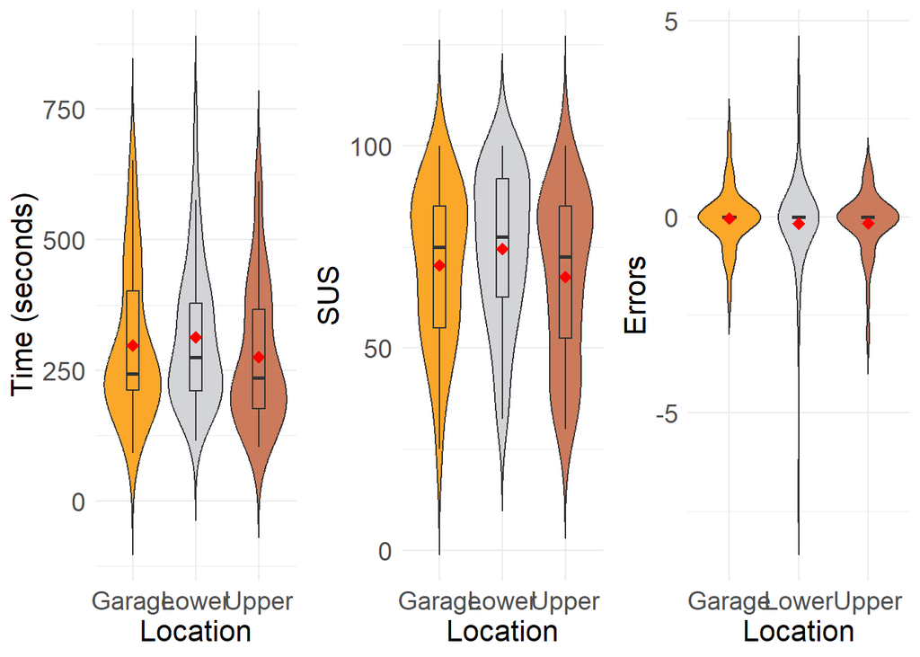

```r
# Adjusting plots with increased label sizes
p1 <- ggplot(data, aes(x = Location, y = TimeSec, fill = Location)) +
  geom_violin(trim = FALSE) +
  geom_boxplot(width = 0.2, fill = NA, outlier.shape = NA) +
  stat_summary(fun = mean, geom = "point", shape = 18, size = 3, color = "red") +
  labs(#title = "Boxplot of Time by Location",
       y = "Time (seconds)", x = "Location") +
  scale_fill_manual(values = wes_palette("AsteroidCity3")) +
  theme_minimal() +
  theme(legend.position = "none",
        #plot.title = element_text(size = 14),
        axis.title = element_text(size = 16),
        axis.text = element_text(size = 14))

p3 <- ggplot(data, aes(x = Location, y = SUS, fill = Location)) +
  geom_violin(trim = FALSE) +
  geom_boxplot(width = 0.2, fill = NA, outlier.shape = NA) +
  stat_summary(fun = mean, geom = "point", shape = 18, size = 3, color = "red") +
  labs(#title = "Boxplot of SUS by Location",
       y = "SUS", x = "Location") +
  scale_fill_manual(values = wes_palette("AsteroidCity3")) +
  theme_minimal() +
  theme(legend.position = "none",
        #plot.title = element_text(size = 14),
        axis.title = element_text(size = 16),
        axis.text = element_text(size = 14))

p5 <- ggplot(data, aes(x = Location, y = Error, fill = Location)) +
  geom_violin(trim = FALSE) +
  geom_boxplot(width = 0.2, fill = NA, outlier.shape = NA) +
  stat_summary(fun = mean, geom = "point", shape = 18, size = 3, color = "red") +
  labs(#title = "Boxplot of Errors by Location",
       y = "Errors", x = "Location") +
  scale_fill_manual(values = wes_palette("AsteroidCity3")) +
  theme_minimal() +
  theme(legend.position = "none",
        #plot.title = element_text(size = 14),
        axis.title = element_text(size = 16),
        axis.text = element_text(size = 14))

# Combine the plots
grid_plot <- grid.arrange(p1, p3, p5, ncol = 3, nrow = 1)
```

```r
# Export to PNG
ggsave("EDA_Location.png", grid_plot, width = 16, height = 12)
```

```r
# Add a row identifier to the original data
data <- data %>% mutate(row_id = row_number())

# Merge with grouped_stats to get the mean and SD
data.stats <- data %>% left_join(grouped_stats, by = c(#"Location",
                                                       "System"))

# Identify outliers
outliers_TimeSec <- data.stats %>% filter(abs(TimeSec - Time_Mean) > 3 * Time_SD) #%>% select(row_id)
outliers_Error <- data.stats %>% filter(abs(Error - Error_Mean) > 3 * Error_SD) #%>% select(row_id)
outliers_SUS <- data.stats %>% filter(abs(SUS - SUS_Mean) > 3 * SUS_SD) #%>% select(row_id)

# Combine all outlier identifiers
all_outliers <- bind_rows(outliers_TimeSec, outliers_Error, outliers_SUS) %>% distinct()

# Remove the identified outliers from the original data
clean_data <- data.stats %>%
  filter(!(row_id %in% all_outliers$row_id)) %>%
  select(-row_id, -starts_with("Time_"), -starts_with("Error_"), -starts_with("SUS_"))
```

Some outliers were found

```r
data <- clean_data
count(all_outliers)
```

```
##   n
## 1 6
```

Data cleaned by removing outliers greater than 3 standard deviations away from the mean.

```r
grouped_stats <- data %>%
  group_by(#Location,
           System
           ) %>%
  summarise(
    n = n(),  # Count the number of non-NA observations in the group
    Time_Mean = mean(TimeSec, na.rm = TRUE),
    Time_SD = sd(TimeSec, na.rm = TRUE),
    Time_Median = median(TimeSec, na.rm = TRUE),
    Error_Mean = mean(Error, na.rm = TRUE),
    Error_SD = sd(Error, na.rm = TRUE),
    Error_Median = median(Error, na.rm = TRUE),
    SUS_Mean = mean(SUS, na.rm = TRUE),
    SUS_SD = sd(SUS, na.rm = TRUE),
    SUS_Median = median(SUS, na.rm = TRUE),
    .groups = 'drop'  # This will prevent the grouping to affect subsequent operations
  )
grouped_stats
```

```
## # A tibble: 3 × 11
##   System     n Time_Mean Time_SD Time_Median Error_Mean Error_SD Error_Median
##   <chr>  <int>     <dbl>   <dbl>       <dbl>      <dbl>    <dbl>        <int>
## 1 DPM       35      447.   114.          419    -0.0857    0.612            0
## 2 NFC       39      203.    69.5         192    -0.0256    0.628            0
## 3 QR        39      237.    50.8         235    -0.231     0.902            0
## # ℹ 3 more variables: SUS_Mean <dbl>, SUS_SD <dbl>, SUS_Median <dbl>
```

## Exploring Data

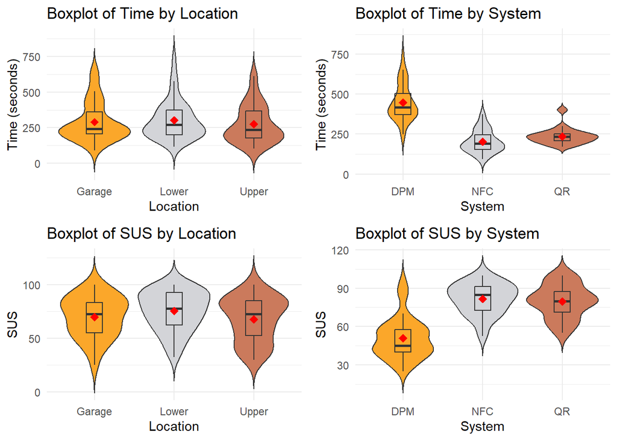

```r
# Assuming 'data' is your data frame and the plots have been defined as follows:
p1 <- ggplot(data, aes(x = Location, y = TimeSec, fill = Location)) +
  geom_violin(trim = FALSE) +
  geom_boxplot(width = 0.2, fill = NA, outlier.shape = NA) +
  stat_summary(fun = mean, geom = "point", shape = 18, size = 3, color = "red") +
  labs(title = "Boxplot of Time by Location", y = "Time (seconds)", x = "Location") +
  scale_fill_manual(values = wes_palette("AsteroidCity3")) +
  theme_minimal() +
  theme(legend.position = "none")

p2 <- ggplot(data, aes(x = System, y = TimeSec, fill = System)) +
  geom_violin(trim = FALSE) +
  geom_boxplot(width = 0.2, fill = NA, outlier.shape = NA) +
  stat_summary(fun = mean, geom = "point", shape = 18, size = 3, color = "red") +
  labs(title = "Boxplot of Time by System", y = "Time (seconds)", x = "System") +
  scale_fill_manual(values = wes_palette("AsteroidCity3")) +
  theme_minimal() +
  theme(legend.position = "none")

p3 <- ggplot(data, aes(x = Location, y = SUS, fill = Location)) +
  geom_violin(trim = FALSE) +
  geom_boxplot(width = 0.2, fill = NA, outlier.shape = NA) +
  stat_summary(fun = mean, geom = "point", shape = 18, size = 3, color = "red") +
  labs(title = "Boxplot of SUS by Location", y = "SUS", x = "Location") +
  scale_fill_manual(values = wes_palette("AsteroidCity3")) +
  theme_minimal() +
  theme(legend.position = "none")

p4 <- ggplot(data, aes(x = System, y = SUS, fill = System)) +
  geom_violin(trim = FALSE) +
  geom_boxplot(width = 0.2, fill = NA, outlier.shape = NA) +
  stat_summary(fun = mean, geom = "point", shape = 18, size = 3, color = "red") +
  labs(title = "Boxplot of SUS by System", y = "SUS", x = "System") +
  scale_fill_manual(values = wes_palette("AsteroidCity3")) +
  theme_minimal() +
  theme(legend.position = "none")

# Combine the plots
grid_plot <- grid.arrange(p1, p2, p3, p4, ncol = 2, nrow = 2)
```

```r
# Export to PNG
ggsave("EDA_SUS_Time.png", grid_plot, width = 16, height = 12)
```

## Data spread by location and device

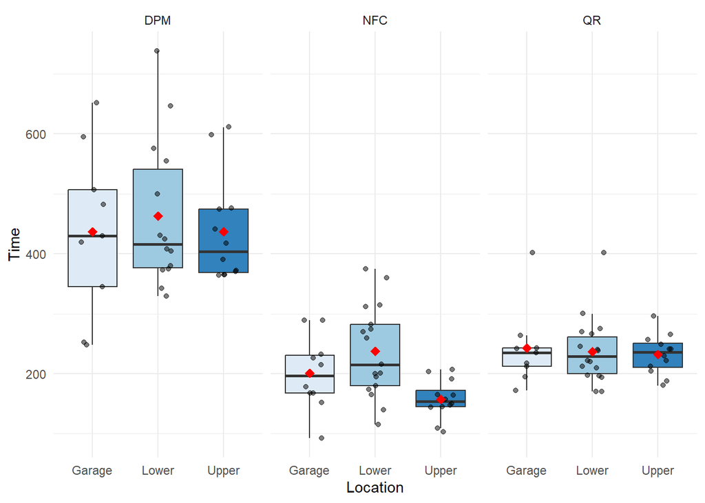

```r
# Replace 'Time' with 'Error' and 'SUS' for the other dependent variables

# Faceting by 'System'
p1 <- ggplot(data, aes(x = Location, y = TimeSec, fill = Location)) +
  geom_boxplot(outlier.shape = NA) + # Hide outliers for cleaner plots
  geom_point(data = data, aes(y = TimeSec), position = position_jitter(width = 0.2), alpha = 0.5) +
  stat_summary(fun = mean, geom = "point", shape = 18, size = 3, color = "red") +
  facet_wrap(~System, scales = "free_x") +
  scale_fill_brewer(palette = "Blues") +
  theme_minimal() +
  theme(legend.position = "none", panel.background = element_blank()) +
  labs(#title = "Boxplot of Time by Location and System",
       y = "Time", x = "Location")

# Faceting by 'System'
p2 <- ggplot(data, aes(x = Location, y = SUS, fill = Location)) +
  geom_boxplot(outlier.shape = NA) + # Hide outliers for cleaner plots
  geom_point(data = data, aes(y = SUS), position = position_jitter(width = 0.2), alpha = 0.5) +
  stat_summary(fun = mean, geom = "point", shape = 18, size = 3, color = "red") +
  facet_wrap(~System, scales = "free_x") +
  #scale_fill_manual(values = wes_palette("AsteroidCity3")) +
  scale_fill_brewer(palette = "Blues") +
  theme_minimal() +
  theme(legend.position = "none") + # Remove the legend
  labs(#title = "Boxplot of SUS by Location and System",
       y = "SUS", x = "Location")

# Faceting by 'System'
p3 <- ggplot(data, aes(x = Location, y = Error, fill = Location)) +
  geom_boxplot(outlier.shape = NA) + # Hide outliers for cleaner plots
  geom_point(data = data, aes(y = Error), position = position_jitter(width = 0.2), alpha = 0.5) +
  stat_summary(fun = mean, geom = "point", shape = 18, size = 3, color = "red") +
  facet_wrap(~System, scales = "free_x") +
  scale_fill_brewer(palette = "Blues") +
  theme_minimal() +
  theme(legend.position = "none") + # Remove the legend
  labs(#title = "Boxplot of Errors by Location and System",
       y = "Errors", x = "Location")

# To print the plots
print(p1)
```

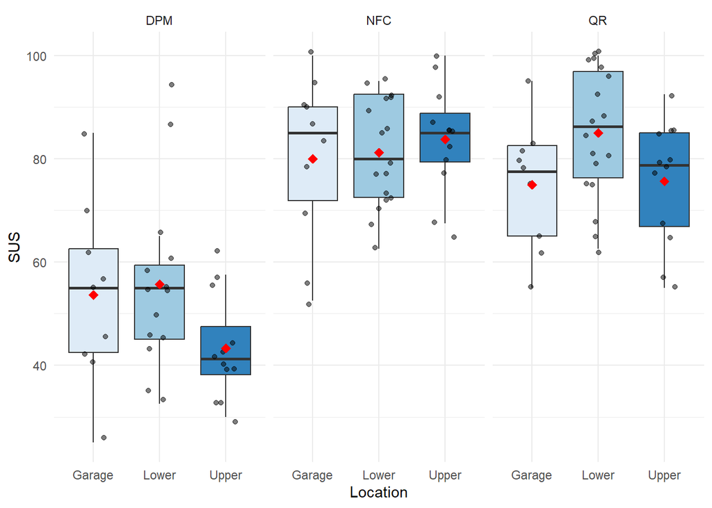

```r
print(p2)
```

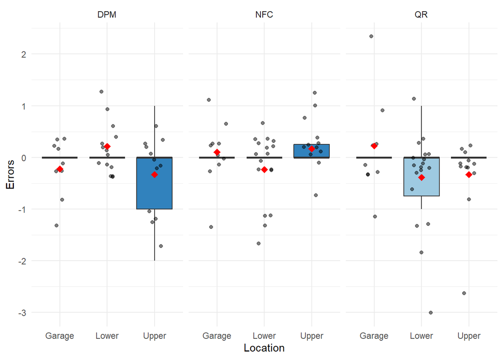

```r
print(p3)
```

```r
# Combine the plots into a single figure
combined_plot <- p1 / p2 / p3

# Use patchwork to align the plots
combined_plot <- combined_plot +
                 plot_layout(guides = 'collect') + # Collect guides and align
                 plot_annotation(tag_levels = 'A') # Add tags if necessary

# Now, save the combined plot to a PNG file
ggsave("combined_scatter_plots.png", combined_plot, width = 16, height = 18)
```

## Correlations?

```r
# Assuming data$Time, data$Error, and data$SUS are numeric
correlation_matrix <- cor(data[,c("TimeSec", "Error", "SUS")], use = "complete.obs")

blue_palette <- colorRampPalette(c("lightblue", "blue"))(200)

# Open a PNG graphics device
png("correlation_plot.png", width = 800, height = 600)

# Create the correlation plot using the blue color palette
corrplot(correlation_matrix, method = "circle",
         #addCoef.col = "black", col = blue_palette,
         #number.cex = 1.5,  # Larger text size for the coefficients
         cl.pos = "r",  # Position the color legend on the right
         tl.col = "black", tl.srt = 45, # Rotate top labels to 45 degrees
         tl.cex = 1.5,  # Larger text size for the labels
         tl.pos = "t")  # Ensure top labels are used

# Close the device
dev.off()
```

# Pre-checks of data for ANOVA Statistical Analysis

## Normality Testing

```r
# Remember to check the assumptions of ANOVA, such as normality of the residuals and homogeneity of variances, before relying on the results. If the assumptions are violated, a non-parametric alternative like the Kruskal-Wallis test might be more appropriate.

# Normality check (using Shapiro-Wilk test):

shapiro.test(data$SUS)
```

```
##
##  Shapiro-Wilk normality test
##
## data:  data$SUS
## W = 0.95007, p-value = 0.0003468
```

```r
shapiro.test(data$TimeSec)
```

```
##
##  Shapiro-Wilk normality test
##
## data:  data$TimeSec
## W = 0.90281, p-value = 5.325e-07
```

```r
shapiro.test(data$Error)
```

```
##
##  Shapiro-Wilk normality test
##
## data:  data$Error
## W = 0.721, p-value = 2.34e-13
```

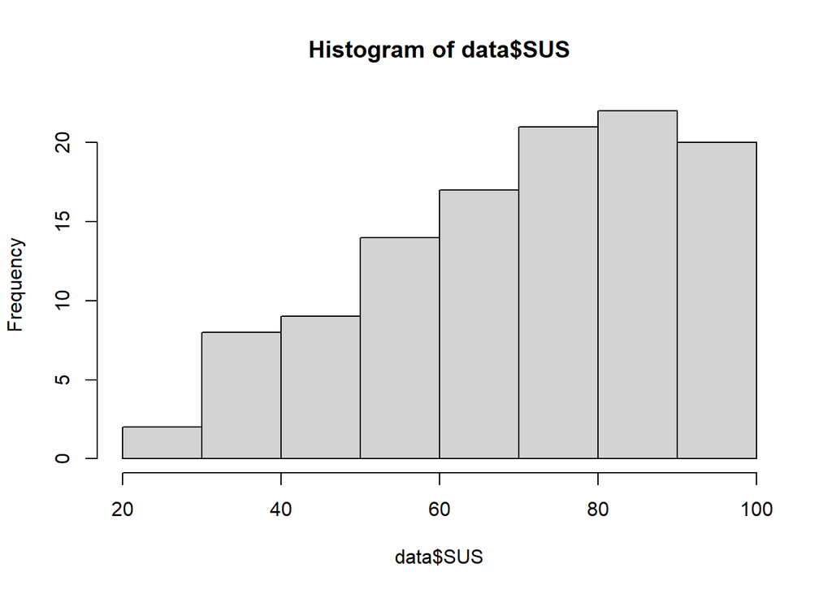

```r
hist(data$SUS)
```

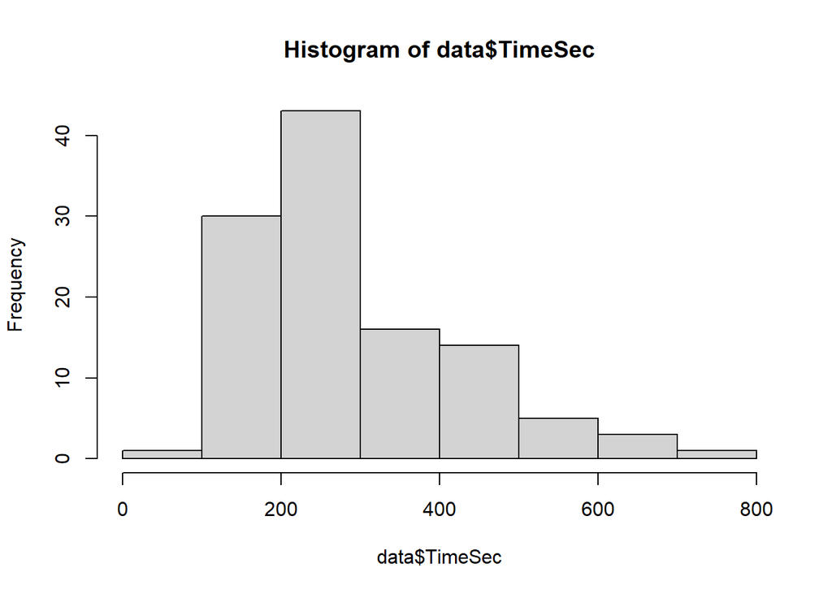

```r
hist(data$TimeSec)
```

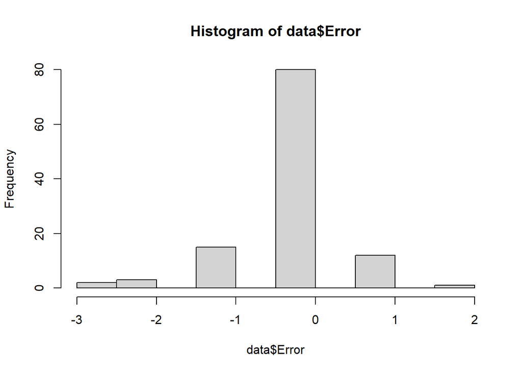

```r
hist(data$Error)
```

Results do not look so normal….

### Log Transform

```r
shapiro.test(data$SUS)
```

```
##
##  Shapiro-Wilk normality test
##
## data:  data$SUS
## W = 0.95007, p-value = 0.0003468
```

```r
shapiro.test(data$TimeSec)
```

```
##
##  Shapiro-Wilk normality test
##
## data:  data$TimeSec
## W = 0.90281, p-value = 5.325e-07
```

```r
shapiro.test(data$Error)
```

```
##
##  Shapiro-Wilk normality test
##
## data:  data$Error
## W = 0.721, p-value = 2.34e-13
```

```r
# Logarithmic transformation (add a small constant if data contains zeros)
constant_to_add <- 1e-6  # This is an arbitrarily small number to offset zero values
data$SUS_log <- log(data$SUS + constant_to_add)
data$TimeSec_log <- log(data$TimeSec + constant_to_add)
data$Error_log <- log(data$Error + constant_to_add)
# Shapiro-Wilk normality test on log-transformed data
shapiro.test(data$SUS_log)
```

```
##
##  Shapiro-Wilk normality test
##
## data:  data$SUS_log
## W = 0.90125, p-value = 4.441e-07
```

```r
shapiro.test(data$TimeSec_log)
```

```
##
##  Shapiro-Wilk normality test
##
## data:  data$TimeSec_log
## W = 0.98444, p-value = 0.2154
```

```r
shapiro.test(data$Error_log)
```

```
##
##  Shapiro-Wilk normality test
##
## data:  data$Error_log
## W = 0.41326, p-value < 2.2e-16
```

noooot great, only log transformation of time works out

### Yeo-Johnson transform Test

```r
# Apply the Yeo-Johnson transformation
transformed_data <- bestNormalize(data$SUS, method = "yeojohnson")

# The transformed data
transformed_values = transformed_data$x.t

# If you need to use the transformed data, you can now work with 'transformed_values'
# or directly with 'transformed_data$x.t'

shapiro.test(transformed_values)
```

```
##
##  Shapiro-Wilk normality test
##
## data:  transformed_values
## W = 0.95426, p-value = 0.0006963
```

### Box-Cox Transform Test

```r
# Assuming 'data' is your data frame and 'Error' is the column to be normalized

# Add the constant to the Error data to ensure all values are positive
constant <- abs(min(data$Error, na.rm = TRUE)) + 1
data$Error_positive <- data$Error + constant

# Ensure that the data is numeric and handle NA or infinite values
data$Error_positive <- as.numeric(data$Error_positive)
data$Error_positive <- na.omit(data$Error_positive)
data$Error_positive <- data$Error_positive[is.finite(data$Error_positive)]

# Check that data$Error_positive is not empty
if(length(data$Error_positive) == 0) {
  stop("Error_positive is empty after processing.")
}

# Box-Cox transformation using the bestNormalize package
library(bestNormalize)
bc_Error <- boxcox(data$Error_positive)

# Ensure that the Box-Cox transformation was successful and 'bc_Error' contains the lambda
if(is.null(bc_Error$lambda) || length(bc_Error$lambda) == 0) {
  stop("boxcox transformation did not return a valid lambda value.")
}

# Extract the lambda value
lambda_Error <- bc_Error$lambda

# Perform the Box-Cox transformation using the optimal lambda
data$Error_bc <- if(lambda_Error == 0) {
  log(data$Error_positive)
} else {
  (data$Error_positive^lambda_Error - 1) / lambda_Error
}

# Conduct the Shapiro-Wilk test to check for normality
shapiro_test_result <- shapiro.test(data$Error_bc)

# Output the Shapiro-Wilk test result
print(shapiro_test_result)
```

```
##
##  Shapiro-Wilk normality test
##
## data:  data$Error_bc
## W = 0.74781, p-value = 1.203e-12
```

## Homoscedasticity Testing

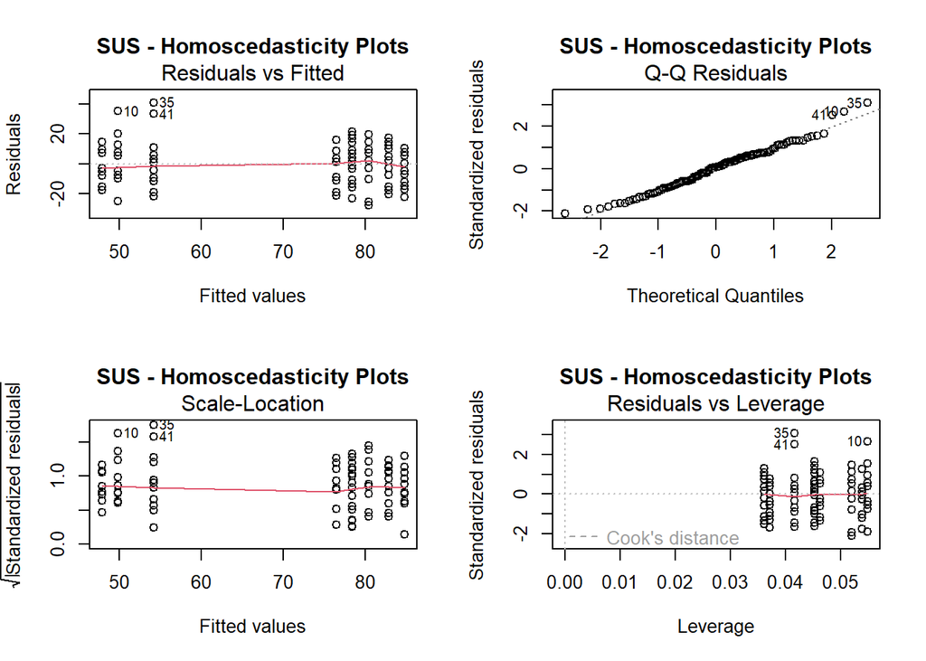

```r
# Assuming 'model' is your ANOVA model
model.SUS <- aov(SUS ~ Location + System, data = data)
model.Error <- aov(Error ~ Location + System, data = data)
model.TimeSec <- aov(TimeSec ~ Location + System, data = data)

# Generate diagnostic plots
par(mfrow = c(2, 2))  # Set up the plotting area to show 4 plots
plot(model.SUS, main = "SUS - Homoscedasticity Plots")  # Generates four diagnostic plots, including Residuals vs. Fitted
```

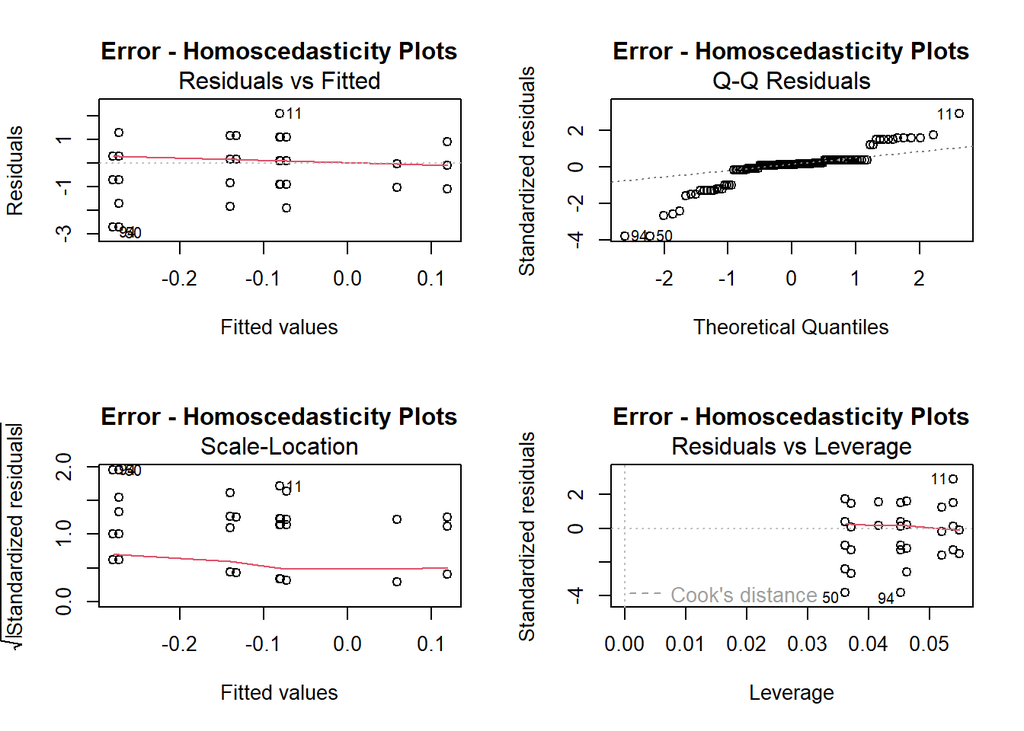

```r
plot(model.Error, main = "Error - Homoscedasticity Plots")
```

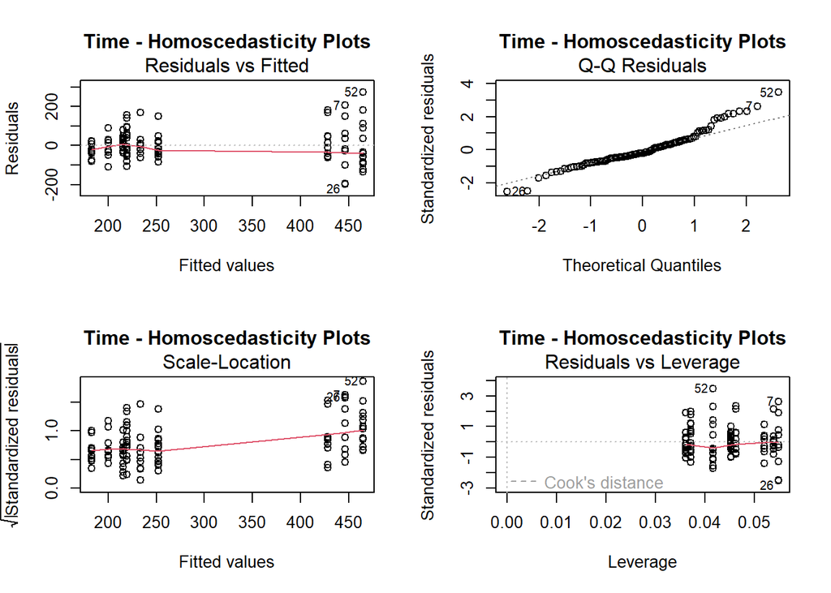

```r
plot(model.TimeSec, main = "Time - Homoscedasticity Plots")
```

```r
par(mfrow = c(1, 1))  # Reset to default plotting settings
```

Summary: Data does not pass checks like normality and ANOVA testing shouldn’t be used.

# Alternative Analyses when not passing ANOVA assumptions

## use non-parametric Kruskal-Wallis

Does not assume a normal distribution of data or equal variances across groups

```r
# For 'Error' as DV
kw_error_location <- kruskal.test(Error ~ Location, data = data)
kw_error_system <- kruskal.test(Error ~ System, data = data)

# For 'TimeSec' as DV
kw_timesec_location <- kruskal.test(TimeSec ~ Location, data = data)
kw_timesec_system <- kruskal.test(TimeSec ~ System, data = data)

# For 'SUS' as DV
kw_sus_location <- kruskal.test(SUS ~ Location, data = data)
kw_sus_system <- kruskal.test(SUS ~ System, data = data)

# Print the results
list(
  Error_Location = kw_error_location,
  Error_System = kw_error_system,
  TimeSec_Location = kw_timesec_location,
  TimeSec_System = kw_timesec_system,
  SUS_Location = kw_sus_location,
  SUS_System = kw_sus_system
)
```

```
## $Error_Location
##
##  Kruskal-Wallis rank sum test
##
## data:  Error by Location
## Kruskal-Wallis chi-squared = 0.66888, df = 2, p-value = 0.7157
##
##
## $Error_System
##
##  Kruskal-Wallis rank sum test
##
## data:  Error by System
## Kruskal-Wallis chi-squared = 1.168, df = 2, p-value = 0.5577
##
##
## $TimeSec_Location
##
##  Kruskal-Wallis rank sum test
##
## data:  TimeSec by Location
## Kruskal-Wallis chi-squared = 1.6027, df = 2, p-value = 0.4487
##
##
## $TimeSec_System
##
##  Kruskal-Wallis rank sum test
##
## data:  TimeSec by System
## Kruskal-Wallis chi-squared = 68.03, df = 2, p-value = 1.689e-15
##
##
## $SUS_Location
##
##  Kruskal-Wallis rank sum test
##
## data:  SUS by Location
## Kruskal-Wallis chi-squared = 3.3613, df = 2, p-value = 0.1863
##
##
## $SUS_System
##
##  Kruskal-Wallis rank sum test
##
## data:  SUS by System
## Kruskal-Wallis chi-squared = 49.224, df = 2, p-value = 2.047e-11
```

No significant difference in Error across different Locations and Systems. TimeSec and SUS scores are significantly affected by the System, but not by the Location.

```r
# Post hoc test for 'TimeSec' by 'System'
dunn_test_result_TimeSec <- dunn.test(data$TimeSec, data$System, method="bonferroni")
```

```
##   Kruskal-Wallis rank sum test
##
## data: x and group
## Kruskal-Wallis chi-squared = 68.0298, df = 2, p-value = 0
##
##
##                            Comparison of x by group
##                                  (Bonferroni)
## Col Mean-|
## Row Mean |        DPM        NFC
## ---------+----------------------
##      NFC |   7.971739
##          |    0.0000*
##       QR |   6.000352  -2.026929
##          |    0.0000*     0.0640
##
## alpha = 0.05
## Reject Ho if p <= alpha/2
```

```r
# Post hoc test for 'SUS' by 'System'
dunn_test_result_SUS <- dunn.test(data$SUS, data$System, method="bonferroni")
```

```
##   Kruskal-Wallis rank sum test
##
## data: x and group
## Kruskal-Wallis chi-squared = 49.2242, df = 2, p-value = 0
##
##
##                            Comparison of x by group
##                                  (Bonferroni)
## Col Mean-|
## Row Mean |        DPM        NFC
## ---------+----------------------
##      NFC |  -6.376318
##          |    0.0000*
##       QR |  -5.847923   0.543282
##          |    0.0000*     0.8804
##
## alpha = 0.05
## Reject Ho if p <= alpha/2
```

```r
# Print the results
print(dunn_test_result_TimeSec)
```

```
## $chi2
## [1] 68.02982
##
## $Z
## [1]  7.971739  6.000353 -2.026930
##
## $P
## [1] 7.822828e-16 9.844472e-10 2.133481e-02
##
## $P.adjusted
## [1] 2.346848e-15 2.953342e-09 6.400443e-02
##
## $comparisons
## [1] "DPM - NFC" "DPM - QR"  "NFC - QR"
```

```r
print(dunn_test_result_SUS)
```

```
## $chi2
## [1] 49.22425
##
## $Z
## [1] -6.3763185 -5.8479235  0.5432822
##
## $P
## [1] 9.069774e-11 2.488736e-09 2.934677e-01
##
## $P.adjusted
## [1] 2.720932e-10 7.466208e-09 8.804032e-01
##
## $comparisons
## [1] "DPM - NFC" "DPM - QR"  "NFC - QR"
```

There are significant differences between the groups DPM and NFC, and DPM and QR in both analyses, as evidenced by the very low p-values. The comparisons between NFC and QR are not statistically significant in both analyses, with p-values above the 0.05 threshold.

## Adonis PermANOVA/PerMANOVA:

As this requires the least amount of data-modification, this PermANOVA was reported in the paper. As the error data contains negative values, +10 was added to each value to avoid errors in the calculation.

### One-way PermANOVA:

```r
a_permutation_anova_timeo <- adonis(data$TimeSec ~ Location + System, data = data, permutations = 999)
```

```
## 'adonis' will be deprecated: use 'adonis2' instead
```

```r
data_error <- data %>%
    mutate(Error = Error + 10.00000)
a_permutation_anova_erroro <- adonis(data_error$Error ~ Location + System, data = data_error, permutations = 999)
```

```
## 'adonis' will be deprecated: use 'adonis2' instead
```

```r
a_permutation_anova_suso <- adonis(data$SUS ~ Location + System, data = data, permutations = 999)
```

```
## 'adonis' will be deprecated: use 'adonis2' instead
```

```r
# Print the results
print("Permutation ANOVA for TimeSec:")
```

```
## [1] "Permutation ANOVA for TimeSec:"
```

```r
print(a_permutation_anova_timeo)
```

```
## $aov.tab
## Permutation: free
## Number of permutations: 999
##
## Terms added sequentially (first to last)
##
##            Df SumsOfSqs MeanSqs F.Model      R2 Pr(>F)
## Location    2    0.0516 0.02578   1.581 0.01138  0.203
## System      2    2.7190 1.35948  83.353 0.59995  0.001 ***
## Residuals 108    1.7615 0.01631         0.38867
## Total     112    4.5320                 1.00000
## ---
## Signif. codes:  0 '***' 0.001 '**' 0.01 '*' 0.05 '.' 0.1 ' ' 1
##
## $call
```

[output cut: 1291 more lines]

```r
print("Permutation ANOVA for Error:")
```

```
## [1] "Permutation ANOVA for Error:"
```

```r
print(a_permutation_anova_erroro)
```

```
## $aov.tab
## Permutation: free
## Number of permutations: 999
##
## Terms added sequentially (first to last)
##
##            Df SumsOfSqs   MeanSqs F.Model      R2 Pr(>F)
## Location    2  0.002341 0.0011703 0.76532 0.01376  0.454
## System      2  0.002671 0.0013357 0.87347 0.01570  0.413
## Residuals 108  0.165155 0.0015292         0.97055
## Total     112  0.170167                   1.00000
##
## $call
## adonis(formula = data_error$Error ~ Location + System, data = data_error,
##     permutations = 999)
```

[output cut: 1319 more lines]

```r
print("Permutation ANOVA for SUS:")
```

```
## [1] "Permutation ANOVA for SUS:"
```

```r
print(a_permutation_anova_suso)
```

```
## $aov.tab
## Permutation: free
## Number of permutations: 999
##
## Terms added sequentially (first to last)
##
##            Df SumsOfSqs MeanSqs F.Model      R2 Pr(>F)
## Location    2   0.07454 0.03727   3.433 0.02959  0.037 *
## System      2   1.27191 0.63595  58.582 0.50495  0.001 ***
## Residuals 108   1.17242 0.01086         0.46545
## Total     112   2.51886                 1.00000
## ---
## Signif. codes:  0 '***' 0.001 '**' 0.01 '*' 0.05 '.' 0.1 ' ' 1
##
## $call
```

[output cut: 1290 more lines]

Note the message was provided on “‘adonis’ will be deprecated: use ‘adonis2’ instead” adonis2 analysis is provided in the appendix as additional data transforms were needed to use the new package.

### Two-way PermANOVA:

```r
a_permutation_anova_timet <- adonis(data$TimeSec ~ Location * System, data = data, permutations = 999)
```

```
## 'adonis' will be deprecated: use 'adonis2' instead
```

```r
data_error <- data %>%
    mutate(Error = Error + 10.00000)
a_permutation_anova_errort <- adonis(data_error$Error ~ Location * System, data = data_error, permutations = 999)
```

```
## 'adonis' will be deprecated: use 'adonis2' instead
```

```r
a_permutation_anova_sust <- adonis(data$SUS ~ Location * System, data = data, permutations = 999)
```

```
## 'adonis' will be deprecated: use 'adonis2' instead
```

```r
# Print the results
print("Permutation ANOVA for TimeSec:")
```

```
## [1] "Permutation ANOVA for TimeSec:"
```

```r
print(a_permutation_anova_timet)
```

```
## $aov.tab
## Permutation: free
## Number of permutations: 999
##
## Terms added sequentially (first to last)
##
##                  Df SumsOfSqs MeanSqs F.Model      R2 Pr(>F)
## Location          2    0.0516 0.02578   1.664 0.01138  0.193
## System            2    2.7190 1.35948  87.743 0.59995  0.001 ***
## Location:System   4    0.1501 0.03753   2.422 0.03312  0.052 .
## Residuals       104    1.6114 0.01549         0.35555
## Total           112    4.5320                 1.00000
## ---
## Signif. codes:  0 '***' 0.001 '**' 0.01 '*' 0.05 '.' 0.1 ' ' 1
##
```

[output cut: 1562 more lines]

```r
print("Permutation ANOVA for Error:")
```

```
## [1] "Permutation ANOVA for Error:"
```

```r
print(a_permutation_anova_errort)
```

```
## $aov.tab
## Permutation: free
## Number of permutations: 999
##
## Terms added sequentially (first to last)
##
##                  Df SumsOfSqs   MeanSqs F.Model      R2 Pr(>F)
## Location          2  0.002341 0.0011703 0.80195 0.01376  0.452
## System            2  0.002671 0.0013357 0.91529 0.01570  0.424
## Location:System   4  0.013383 0.0033456 2.29255 0.07864  0.080 .
## Residuals       104  0.151773 0.0014594         0.89190
## Total           112  0.170167                   1.00000
## ---
## Signif. codes:  0 '***' 0.001 '**' 0.01 '*' 0.05 '.' 0.1 ' ' 1
##
```

[output cut: 1562 more lines]

```r
print("Permutation ANOVA for SUS:")
```

```
## [1] "Permutation ANOVA for SUS:"
```

```r
print(a_permutation_anova_sust)
```

```
## $aov.tab
## Permutation: free
## Number of permutations: 999
##
## Terms added sequentially (first to last)
##
##                  Df SumsOfSqs MeanSqs F.Model      R2 Pr(>F)
## Location          2   0.07454 0.03727   3.528 0.02959  0.036 *
## System            2   1.27191 0.63595  60.194 0.50495  0.001 ***
## Location:System   4   0.07365 0.01841   1.743 0.02924  0.137
## Residuals       104   1.09877 0.01057         0.43622
## Total           112   2.51886                 1.00000
## ---
## Signif. codes:  0 '***' 0.001 '**' 0.01 '*' 0.05 '.' 0.1 ' ' 1
##
```

[output cut: 1561 more lines]

### PermANOVA AIC test for model fit

```r
# Extract Values manually from Results of ANOVA decimal normalisation
a_RSSoT <- 2.2132
a_RSSoE <- 0.48889
a_RSSoS <- 1.45511
a_RSStT <- 2.0123
a_RSStE <- 0.45558
a_RSStS <- 1.35309
k <- 4
n <- 118

# AIC one way dec
a_LoT <- (1 / sqrt(2 * pi))^n * exp(-a_RSSoT / 2)
a_LoE <- (1 / sqrt(2 * pi))^n * exp(-a_RSSoE / 2)
a_LoS <- (1 / sqrt(2 * pi))^n * exp(-a_RSSoS / 2)

a_AIC_value_oT <- 2 * k - 2 * log(a_LoT)
a_AIC_value_oE <- 2 * k - 2 * log(a_LoE)
a_AIC_value_oS <- 2 * k - 2 * log(a_LoS)

# AIC two way dec
a_LtT <- (1 / sqrt(2 * pi))^n * exp(-a_RSStT / 2)
a_LtE <- (1 / sqrt(2 * pi))^n * exp(-a_RSStE / 2)
a_LtS <- (1 / sqrt(2 * pi))^n * exp(-a_RSStS / 2)

a_AIC_value_tT <- 2 * k - 2 * log(a_LtT)
a_AIC_value_tE <- 2 * k - 2 * log(a_LtE)
a_AIC_value_tS <- 2 * k - 2 * log(a_LtS)

# print the Results
print(a_AIC_value_oT)
```

```
## [1] 227.0827
```

```r
print(a_AIC_value_tT)
```

```
## [1] 226.8818
```

```r
print(a_AIC_value_oE)
```

```
## [1] 225.3584
```

```r
print(a_AIC_value_tE)
```

```
## [1] 225.3251
```

```r
print(a_AIC_value_oS)
```

```
## [1] 226.3246
```

```r
print(a_AIC_value_tS)
```

```
## [1] 226.2226
```

As we can see, the AIC-Criterion doesn’t point to a better model. In summary the permutational ANOVA/PERMANOVA support the findings from the previous analysis.

### PerMANOVA:

```r
# errors not equal to 0
data_error <- data %>%
  mutate(Error = Error + 10.0000000000)

# Manova Test
a_manova_result <- manova(cbind(TimeSec, Error, SUS) ~ Location * System, data = data_error)


# adonis for permutation testing
a_perm_test <- adonis(data_error[, c("TimeSec", "Error", "SUS")] ~ Location * System, data = data_error, permutations = 999)
```

```
## 'adonis' will be deprecated: use 'adonis2' instead
```

```r
# Display results
print(a_perm_test)
```

```
## $aov.tab
## Permutation: free
## Number of permutations: 999
##
## Terms added sequentially (first to last)
##
##                  Df SumsOfSqs MeanSqs F.Model      R2 Pr(>F)
## Location          2    0.0173 0.00865   0.730 0.00471  0.516
## System            2    2.3137 1.15683  97.563 0.62986  0.001 ***
## Location:System   4    0.1092 0.02730   2.302 0.02973  0.057 .
## Residuals       104    1.2332 0.01186         0.33571
## Total           112    3.6733                 1.00000
## ---
## Signif. codes:  0 '***' 0.001 '**' 0.01 '*' 0.05 '.' 0.1 ' ' 1
##
```

[output cut: 1562 more lines]

## Hypothesis Testing

### Test for H1) As the level of device digitization increases, reading time will decrease

```r
#data$Site <- factor(data$Location, levels = c("Lower", "Upper", "Garage"), ordered = FALSE)
data$Digitization <- factor(data$System, levels = c("DPM", "QR", "NFC"), ordered = TRUE)

# Conduct the Jonckheere-Terpstra test
print(jonckheere.test(data$TimeSec, data$Digitization))
```

```
##
##  Jonckheere-Terpstra test
##
## data:
## JT = 551, p-value < 2.2e-16
## alternative hypothesis: two.sided
```

```r
# Spearman's correlation test
# Check for sufficient variability
if (length(unique(data$TimeSec)) > 1 && length(unique(data$Digitization)) > 1) {
    # Perform Spearman's rank correlation test
    spearman_result <- cor.test(data$TimeSec, as.numeric(data$Digitization), method = "spearman")
    print(spearman_result)
} else {
    cat("Not enough variability in data for Spearman's correlation test.\n")
}
```

```
##
##  Spearman's rank correlation rho
##
## data:  data$TimeSec and as.numeric(data$Digitization)
## S = 419122, p-value < 2.2e-16
## alternative hypothesis: true rho is not equal to 0
## sample estimates:
##        rho
## -0.7429702
```

### test H2) higher levels of device digitization are anticipated to result in a decrease in the number of errors

```r
# Conduct the Jonckheere-Terpstra test
print(jonckheere.test(data$Error, data$Digitization))
```

```
##
##  Jonckheere-Terpstra test
##
## data:
## JT = 2198.5, p-value = 0.7002
## alternative hypothesis: two.sided
```

```r
# Spearman's correlation test
# Check for sufficient variability
if (length(unique(data$Error)) > 1 && length(unique(data$Digitization)) > 1) {
    # Perform Spearman's rank correlation test
    spearman_result <- cor.test(data$Error, as.numeric(data$Digitization), method = "spearman")
    print(spearman_result)
} else {
    cat("Not enough variability in data for Spearman's correlation test.\n")
}
```

```
##
##  Spearman's rank correlation rho
##
## data:  data$Error and as.numeric(data$Digitization)
## S = 229445, p-value = 0.6298
## alternative hypothesis: true rho is not equal to 0
## sample estimates:
##        rho
## 0.04582282
```

### test for H3) higher levels of device digitization are anticipated to result in greater SUS scores

```r
# Conduct the Jonckheere-Terpstra test
print(jonckheere.test(data$SUS, data$Digitization))
```

```
##
##  Jonckheere-Terpstra test
##
## data:
## JT = 3321, p-value = 2.875e-10
## alternative hypothesis: two.sided
```

```r
# Spearman's correlation test
# Check for sufficient variability
if (length(unique(data$SUS)) > 1 && length(unique(data$Digitization)) > 1) {
    # Perform Spearman's rank correlation test
    spearman_result <- cor.test(data$SUS, as.numeric(data$Digitization), method = "spearman")
    print(spearman_result)
} else {
    cat("Not enough variability in data for Spearman's correlation test.\n")
}
```

```
##
##  Spearman's rank correlation rho
##
## data:  data$SUS and as.numeric(data$Digitization)
## S = 98886, p-value = 6.95e-12
## alternative hypothesis: true rho is not equal to 0
## sample estimates:
##       rho
## 0.5887702
```

# Conclusions

- the selection of the tracking device has impact on speed and user experience
- the differences between NFC and QR Codes are small on their impact on speed and experience, but both had significant impact
- NFC had slightly faster times and slightly higher user experience than QR Code
- DPM is slowest and worst user experience
- Number of errors was not impacted by choice of system or location
- the experiment was run in parallel in different locations, it was shown that location has slight impact on results
- Negative correlation between time and SUS

#Appendix:

## Adonis2 PermANOVA/PerMANOVA not reported in paper due to data transformations:

For Adonis2, the data for each of the dependent variables was transformed into a distance-matrix (method=eucledian). As the residual sum of squares got to big for calculating the AIC, the data was normalized using on one hand scaling by the factor 100 and z-transformation.

```r
# Extract the variables to be normalized
time_sec <- data$TimeSec
error <- data$Error
sus <- data$SUS

# Z-score normalization for each variable
normalized_time_sec <- (time_sec - mean(time_sec)) / sd(time_sec)
normalized_error <- (error - mean(error)) / sd(error)
normalized_sus <- (sus - mean(sus)) / sd(sus)

# Create a new dataset with normalized variables
data_normalized <- data
data_normalized$TimeSec <- normalized_time_sec
data_normalized$Error <- normalized_error
data_normalized$SUS <- normalized_sus

# Conduct permutation ANOVA for each dependent variable

data_matrixT <- data_normalized[, c("TimeSec")]
datadistT <- vegdist(data_matrixT, method = "euclidean")
a2z_permutation_anova_time <- adonis2(datadistT ~ Location + System, data = data_normalized, permutations = 999)

data_matrixE <- data_normalized[, c("Error")]
datadistE <- vegdist(data_matrixE, method = "euclidean")
a2z_permutation_anova_error <- adonis2(datadistE ~ Location + System, data = data_normalized, permutations = 999)

data_matrixS <- data_normalized[, c("SUS")]
datadistS <- vegdist(data_matrixS, method = "euclidean")
a2z_permutation_anova_sus <- adonis2(datadistS ~ Location + System, data = data_normalized, permutations = 999)

# Print the results
print("Permutation ANOVA for TimeSec:")
```

```
## [1] "Permutation ANOVA for TimeSec:"
```

```r
print(a2z_permutation_anova_time)
```

```
## Permutation test for adonis under reduced model
## Terms added sequentially (first to last)
## Permutation: free
## Number of permutations: 999
##
## adonis2(formula = datadistT ~ Location + System, data = data_normalized, permutations = 999)
##           Df SumOfSqs      R2       F Pr(>F)
## Location   2    0.791 0.00707  1.0914  0.358
## System     2   72.047 0.64328 99.3474  0.001 ***
## Residual 108   39.161 0.34965
## Total    112  112.000 1.00000
## ---
## Signif. codes:  0 '***' 0.001 '**' 0.01 '*' 0.05 '.' 0.1 ' ' 1
```

```r
print("Permutation ANOVA for Error:")
```

```
## [1] "Permutation ANOVA for Error:"
```

```r
print(a2z_permutation_anova_error)
```

```
## Permutation test for adonis under reduced model
## Terms added sequentially (first to last)
## Permutation: free
## Number of permutations: 999
##
## adonis2(formula = datadistE ~ Location + System, data = data_normalized, permutations = 999)
##           Df SumOfSqs      R2      F Pr(>F)
## Location   2    1.593 0.01422 0.7901  0.482
## System     2    1.543 0.01377 0.7652  0.455
## Residual 108  108.864 0.97200
## Total    112  112.000 1.00000
```

```r
print("Permutation ANOVA for SUS:")
```

```
## [1] "Permutation ANOVA for SUS:"
```

```r
print(a2z_permutation_anova_sus)
```

```
## Permutation test for adonis under reduced model
## Terms added sequentially (first to last)
## Permutation: free
## Number of permutations: 999
##
## adonis2(formula = datadistS ~ Location + System, data = data_normalized, permutations = 999)
##           Df SumOfSqs      R2       F Pr(>F)
## Location   2    3.548 0.03168  3.6523  0.031 *
## System     2   55.991 0.49992 57.6333  0.001 ***
## Residual 108   52.461 0.46840
## Total    112  112.000 1.00000
## ---
## Signif. codes:  0 '***' 0.001 '**' 0.01 '*' 0.05 '.' 0.1 ' ' 1
```

```r
# Extract the variables to be normalized
time_sec <- data$TimeSec
error <- data$Error
sus <- data$SUS

# Z-score normalization for each variable
normalized_time_sec <- (time_sec - mean(time_sec)) / sd(time_sec)
normalized_error <- (error - mean(error)) / sd(error)
normalized_sus <- (sus - mean(sus)) / sd(sus)

# Create a new dataset with normalized variables
data_normalized <- data
data_normalized$TimeSec <- normalized_time_sec
data_normalized$Error <- normalized_error
data_normalized$SUS <- normalized_sus

# Conduct permutation ANOVA for each dependent variable

data_matrixT <- data_normalized[, c("TimeSec")]
datadistT <- vegdist(data_matrixT, method = "manhattan")
a2z_two_permutation_anova_time <- adonis2(datadistT ~ Location * System, data = data_normalized, permutations = 999)

data_matrixE <- data_normalized[, c("Error")]
datadistE <- vegdist(data_matrixE, method = "euclidean")
a2z_two_permutation_anova_error <- adonis2(datadistE ~ Location * System, data = data_error, permutations = 999)

data_matrixS <- data_normalized[, c("SUS")]
datadistS <- vegdist(data_matrixS, method = "euclidean")
a2z_two_permutation_anova_sus <- adonis2(datadistS ~ Location * System, data = data_normalized, permutations = 999)

# Print the results
print("Permutation ANOVA for TimeSec:")
```

```
## [1] "Permutation ANOVA for TimeSec:"
```

```r
print(a2z_two_permutation_anova_time)
```

```
## Permutation test for adonis under reduced model
## Terms added sequentially (first to last)
## Permutation: free
## Number of permutations: 999
##
## adonis2(formula = datadistT ~ Location * System, data = data_normalized, permutations = 999)
##                  Df SumOfSqs      R2       F Pr(>F)
## Location          2    0.791 0.00707  1.0873  0.347
## System            2   72.047 0.64328 98.9747  0.001 ***
## Location:System   4    1.308 0.01168  0.8987  0.465
## Residual        104   37.853 0.33797
## Total           112  112.000 1.00000
## ---
## Signif. codes:  0 '***' 0.001 '**' 0.01 '*' 0.05 '.' 0.1 ' ' 1
```

```r
print("Permutation ANOVA for Error:")
```

```
## [1] "Permutation ANOVA for Error:"
```

```r
print(a2z_two_permutation_anova_error)
```

```
## Permutation test for adonis under reduced model
## Terms added sequentially (first to last)
## Permutation: free
## Number of permutations: 999
##
## adonis2(formula = datadistE ~ Location * System, data = data_error, permutations = 999)
##                  Df SumOfSqs      R2      F Pr(>F)
## Location          2    1.593 0.01422 0.8349  0.436
## System            2    1.543 0.01377 0.8087  0.459
## Location:System   4    9.663 0.08627 2.5325  0.047 *
## Residual        104   99.202 0.88573
## Total           112  112.000 1.00000
## ---
## Signif. codes:  0 '***' 0.001 '**' 0.01 '*' 0.05 '.' 0.1 ' ' 1
```

```r
print("Permutation ANOVA for SUS:")
```

```
## [1] "Permutation ANOVA for SUS:"
```

```r
print(a2z_two_permutation_anova_sus)
```

```
## Permutation test for adonis under reduced model
## Terms added sequentially (first to last)
## Permutation: free
## Number of permutations: 999
##
## adonis2(formula = datadistS ~ Location * System, data = data_normalized, permutations = 999)
##                  Df SumOfSqs      R2       F Pr(>F)
## Location          2    3.548 0.03168  3.7381  0.024 *
## System            2   55.991 0.49992 58.9867  0.001 ***
## Location:System   4    3.102 0.02770  1.6340  0.171
## Residual        104   49.359 0.44070
## Total           112  112.000 1.00000
## ---
## Signif. codes:  0 '***' 0.001 '**' 0.01 '*' 0.05 '.' 0.1 ' ' 1
```

```r
# Extract Values manually from Results of ANOVA decimal normalisation
a2z_RSSoT <- 39.161
a2z_RSSoE <- 108.864
a2z_RSSoS <- 52.461
a2z_RSStT <- 37.853
a2z_RSStE <- 99.202
a2z_RSStS <- 49.359
k <- 4
n <- 118

# AIC one way dec
a2z_LoT <- (1 / sqrt(2 * pi))^n * exp(-a2z_RSSoT / 2)
a2z_LoE <- (1 / sqrt(2 * pi))^n * exp(-a2z_RSSoE / 2)
a2z_LoS <- (1 / sqrt(2 * pi))^n * exp(-a2z_RSSoS / 2)

a2z_AIC_value_oT <- 2 * k - 2 * log(a2z_LoT)
a2z_AIC_value_oE <- 2 * k - 2 * log(a2z_LoE)
a2z_AIC_value_oS <- 2 * k - 2 * log(a2z_LoS)

# AIC two way dec
a2z_LtT <- (1 / sqrt(2 * pi))^n * exp(-a2z_RSStT / 2)
a2z_LtE <- (1 / sqrt(2 * pi))^n * exp(-a2z_RSStE / 2)
a2z_LtS <- (1 / sqrt(2 * pi))^n * exp(-a2z_RSStS / 2)

a2z_AIC_value_tT <- 2 * k - 2 * log(a2z_LtT)
a2z_AIC_value_tE <- 2 * k - 2 * log(a2z_LtE)
a2z_AIC_value_tS <- 2 * k - 2 * log(a2z_LtS)

# print the Results
print(a2z_AIC_value_oT)
```

```
## [1] 264.0305
```

```r
print(a2z_AIC_value_tT)
```

```
## [1] 262.7225
```

```r
print(a2z_AIC_value_oE)
```

```
## [1] 333.7335
```

```r
print(a2z_AIC_value_tE)
```

```
## [1] 324.0715
```

```r
print(a2z_AIC_value_oS)
```

```
## [1] 277.3305
```

```r
print(a2z_AIC_value_tS)
```

```
## [1] 274.2285
```

```r
# Extract the variables to be normalized
time_sec <- data$TimeSec
error <- data$Error
sus <- data$SUS

# Choose the scaling factor
scaling_factor <- 100

# Decimal scaling for each variable
scaled_time_sec <- time_sec / scaling_factor
scaled_error <- error / scaling_factor
scaled_sus <- sus / scaling_factor

# Create a new dataset with scaled variables
data_scaled <- data
data_scaled$TimeSec <- scaled_time_sec
data_scaled$Error <- scaled_error
data_scaled$SUS <- scaled_sus

# Conduct permutation ANOVA for each dependent variable

data_matrixT <- data_scaled[, c("TimeSec")]
datadistT <- vegdist(data_matrixT, method = "manhattan")
a2dec_permutation_anova_time <- adonis2(datadistT ~ Location + System, data = data_scaled, permutations = 999)

data_matrixE <- data_normalized[, c("Error")]
datadistE <- vegdist(data_matrixE, method = "euclidean")
a2dec_permutation_anova_error <- adonis2(datadistE ~ Location + System, data = data_normalized, permutations = 999)

data_matrixS <- data_scaled[, c("SUS")]
datadistS <- vegdist(data_matrixS, method = "euclidean")
a2dec_permutation_anova_sus <- adonis2(datadistS ~ Location + System, data = data_scaled, permutations = 999)

# Print the results
print("Permutation ANOVA for TimeSec:")
```

```
## [1] "Permutation ANOVA for TimeSec:"
```

```r
print(a2dec_permutation_anova_time)
```

```
## Permutation test for adonis under reduced model
## Terms added sequentially (first to last)
## Permutation: free
## Number of permutations: 999
##
## adonis2(formula = datadistT ~ Location + System, data = data_scaled, permutations = 999)
##           Df SumOfSqs      R2       F Pr(>F)
## Location   2    1.411 0.00707  1.0914  0.334
## System     2  128.459 0.64328 99.3474  0.001 ***
## Residual 108   69.824 0.34965
## Total    112  199.694 1.00000
## ---
## Signif. codes:  0 '***' 0.001 '**' 0.01 '*' 0.05 '.' 0.1 ' ' 1
```

```r
print("Permutation ANOVA for Error:")
```

```
## [1] "Permutation ANOVA for Error:"
```

```r
print(a2dec_permutation_anova_error)
```

```
## Permutation test for adonis under reduced model
## Terms added sequentially (first to last)
## Permutation: free
## Number of permutations: 999
##
## adonis2(formula = datadistE ~ Location + System, data = data_normalized, permutations = 999)
##           Df SumOfSqs      R2      F Pr(>F)
## Location   2    1.593 0.01422 0.7901  0.454
## System     2    1.543 0.01377 0.7652  0.494
## Residual 108  108.864 0.97200
## Total    112  112.000 1.00000
```

```r
print("Permutation ANOVA for SUS:")
```

```
## [1] "Permutation ANOVA for SUS:"
```

```r
print(a2dec_permutation_anova_sus)
```

```
## Permutation test for adonis under reduced model
## Terms added sequentially (first to last)
## Permutation: free
## Number of permutations: 999
##
## adonis2(formula = datadistS ~ Location + System, data = data_scaled, permutations = 999)
##           Df SumOfSqs      R2       F Pr(>F)
## Location   2   0.1337 0.03168  3.6523  0.026 *
## System     2   2.1094 0.49992 57.6333  0.001 ***
## Residual 108   1.9764 0.46840
## Total    112   4.2194 1.00000
## ---
## Signif. codes:  0 '***' 0.001 '**' 0.01 '*' 0.05 '.' 0.1 ' ' 1
```

```r
# Extract the variables to be normalized
time_sec <- data$TimeSec
error <- data$Error
sus <- data$SUS

# Choose the scaling factor
scaling_factor <- 100

# Decimal scaling for each variable
scaled_time_sec <- time_sec / scaling_factor
scaled_error <- error / scaling_factor
scaled_sus <- sus / scaling_factor

# Create a new dataset with scaled variables
data_scaled <- data
data_scaled$TimeSec <- scaled_time_sec
data_scaled$Error <- scaled_error
data_scaled$SUS <- scaled_sus

# Conduct permutation ANOVA for each dependent variable

data_matrixT <- data_scaled[, c("TimeSec")]
datadistT <- vegdist(data_matrixT, method = "manhattan")
a2dec_two_permutation_anova_time <- adonis2(datadistT ~ Location * System, data = data_scaled, permutations = 999)

data_matrixE <- data_normalized[, c("Error")]
datadistE <- vegdist(data_matrixE, method = "euclidean")
a2dec_two_permutation_anova_error <- adonis2(datadistE ~ Location * System, data = data_error, permutations = 999)

data_matrixS <- data_scaled[, c("SUS")]
datadistS <- vegdist(data_matrixS, method = "euclidean")
a2dec_two_permutation_anova_sus <- adonis2(datadistS ~ Location * System, data = data_scaled, permutations = 999)

# Print the results
print("Permutation ANOVA for TimeSec:")
```

```
## [1] "Permutation ANOVA for TimeSec:"
```

```r
print(a2dec_two_permutation_anova_time)
```

```
## Permutation test for adonis under reduced model
## Terms added sequentially (first to last)
## Permutation: free
## Number of permutations: 999
##
## adonis2(formula = datadistT ~ Location * System, data = data_scaled, permutations = 999)
##                  Df SumOfSqs      R2       F Pr(>F)
## Location          2    1.411 0.00707  1.0873  0.360
## System            2  128.459 0.64328 98.9747  0.001 ***
## Location:System   4    2.333 0.01168  0.8987  0.450
## Residual        104   67.491 0.33797
## Total           112  199.694 1.00000
## ---
## Signif. codes:  0 '***' 0.001 '**' 0.01 '*' 0.05 '.' 0.1 ' ' 1
```

```r
print("Permutation ANOVA for Error:")
```

```
## [1] "Permutation ANOVA for Error:"
```

```r
print(a2dec_two_permutation_anova_error)
```

```
## Permutation test for adonis under reduced model
## Terms added sequentially (first to last)
## Permutation: free
## Number of permutations: 999
##
## adonis2(formula = datadistE ~ Location * System, data = data_error, permutations = 999)
##                  Df SumOfSqs      R2      F Pr(>F)
## Location          2    1.593 0.01422 0.8349  0.433
## System            2    1.543 0.01377 0.8087  0.413
## Location:System   4    9.663 0.08627 2.5325  0.034 *
## Residual        104   99.202 0.88573
## Total           112  112.000 1.00000
## ---
## Signif. codes:  0 '***' 0.001 '**' 0.01 '*' 0.05 '.' 0.1 ' ' 1
```

```r
print("Permutation ANOVA for SUS:")
```

```
## [1] "Permutation ANOVA for SUS:"
```

```r
print(a2dec_two_permutation_anova_sus)
```

```
## Permutation test for adonis under reduced model
## Terms added sequentially (first to last)
## Permutation: free
## Number of permutations: 999
##
## adonis2(formula = datadistS ~ Location * System, data = data_scaled, permutations = 999)
##                  Df SumOfSqs      R2       F Pr(>F)
## Location          2   0.1337 0.03168  3.7381  0.024 *
## System            2   2.1094 0.49992 58.9867  0.001 ***
## Location:System   4   0.1169 0.02770  1.6340  0.175
## Residual        104   1.8595 0.44070
## Total           112   4.2194 1.00000
## ---
## Signif. codes:  0 '***' 0.001 '**' 0.01 '*' 0.05 '.' 0.1 ' ' 1
```

```r
# Extract Values manually from Results of ANOVA decimal normalisation
a2dec_RSSoT <- 69.824
a2dec_RSSoE <- 108.864
a2dec_RSSoS <- 1.9764
a2dec_RSStT <- 67.491
a2dec_RSStE <- 99.202
a2dec_RSStS <- 1.8595
k <- 4
n <- 118

# AIC one way dec
a2dec_LoT <- (1 / sqrt(2 * pi))^n * exp(-a2dec_RSSoT / 2)
a2dec_LoE <- (1 / sqrt(2 * pi))^n * exp(-a2dec_RSSoE / 2)
a2dec_LoS <- (1 / sqrt(2 * pi))^n * exp(-a2dec_RSSoS / 2)

a2dec_AIC_value_oT <- 2 * k - 2 * log(a2dec_LoT)
a2dec_AIC_value_oE <- 2 * k - 2 * log(a2dec_LoE)
a2dec_AIC_value_oS <- 2 * k - 2 * log(a2dec_LoS)

# AIC two way dec
a2dec_LtT <- (1 / sqrt(2 * pi))^n * exp(-a2dec_RSStT / 2)
a2dec_LtE <- (1 / sqrt(2 * pi))^n * exp(-a2dec_RSStE / 2)
a2dec_LtS <- (1 / sqrt(2 * pi))^n * exp(-a2dec_RSStS / 2)

a2dec_AIC_value_tT <- 2 * k - 2 * log(a2dec_LtT)
a2dec_AIC_value_tE <- 2 * k - 2 * log(a2dec_LtE)
a2dec_AIC_value_tS <- 2 * k - 2 * log(a2dec_LtS)

# print the Results
print(a2dec_AIC_value_oT)
```

```
## [1] 294.6935
```

```r
print(a2dec_AIC_value_tT)
```

```
## [1] 292.3605
```

```r
print(a2dec_AIC_value_oE)
```

```
## [1] 333.7335
```

```r
print(a2dec_AIC_value_tE)
```

```
## [1] 324.0715
```

```r
print(a2dec_AIC_value_oS)
```

```
## [1] 226.8459
```

```r
print(a2dec_AIC_value_tS)
```

```
## [1] 226.729
```

```r
# errors not equal to 0
data_error <- data %>%
  mutate(Error = Error + 10.00000000001)

# Manova Test
manova_result <- manova(cbind(TimeSec, Error, SUS) ~ Location * System, data = data_error)


# adonis for permutation testing
perm_test <- adonis2(data_error[, c("TimeSec", "Error", "SUS")] ~ Location * System, data = data_error, permutations = 999)

# Display results
print(perm_test)
```

```
## Permutation test for adonis under reduced model
## Terms added sequentially (first to last)
## Permutation: free
## Number of permutations: 999
##
## adonis2(formula = data_error[, c("TimeSec", "Error", "SUS")] ~ Location * System, data = data_error, permutations = 999)
##                  Df SumOfSqs      R2       F Pr(>F)
## Location          2   0.0173 0.00471  0.7297  0.495
## System            2   2.3137 0.62986 97.5634  0.001 ***
## Location:System   4   0.1092 0.02973  2.3022  0.050 *
## Residual        104   1.2332 0.33571
## Total           112   3.6733 1.00000
## ---
## Signif. codes:  0 '***' 0.001 '**' 0.01 '*' 0.05 '.' 0.1 ' ' 1
```